# Introduction to Bulk RNAseq data analysis

Last modified: 16 Nov 2023

# Gene Set Testing

The list of differentially expressed genes is sometimes so long that its interpretation becomes cumbersome and time consuming. It may also be very short while some genes have low p-value yet higher than the given threshold.

A common downstream procedure to combine information across genes is gene set testing. It aims at finding pathways or gene networks the differentially expressed genes play a role in.

Various ways exist to test for enrichment of biological pathways. We will look into over representation and gene set enrichment analyses.

A gene set comprises genes that share a biological function, chromosomal location, or any other relevant criterion.

To save time and effort there are a number of packages that make applying these tests to a large number of gene sets simpler, and which will import gene lists for testing from various sources.

Today we will use [`clusterProfiler`](https://yulab-smu.github.io/clusterProfiler-book/index.html).

## Over-representation

This method tests whether genes in a pathway are present in a subset of our data in a higher number than expected by chance (explanations derived from the [clusterProfiler manual](https://yulab-smu.github.io/clusterProfiler-book/index.html)).

Genes in the experiment are split in two ways:

- annotated to the pathway or not
- differentially expressed or not

We can then create a contingency table with:

- rows: genes in pathway or not
- columns: genes differentially expressed or not

And test for independence of the two variables with the Fisher exact test.

### `clusterProfiler`

`clusterprofiler` (Yu et al. 2012) supports direct online access of the current KEGG database (KEGG: Kyoto Encyclopedia of Genes and Genomes), rather than relying on R annotation packages. It also provides some nice visualisation options.

We first search the resource for mouse data:

```r
library(tidyverse)
library(clusterProfiler)

search_kegg_organism('mouse', by='common_name')
```

```
##      kegg_code                            scientific_name
## 20        mmur                         Microcebus murinus
## 22         mmu                               Mus musculus
## 23        mcal                                 Mus caroli
## 24        mpah                                 Mus pahari
## 26        mcoc                            Mastomys coucha
## 29        pleu                        Peromyscus leucopus
## 85        mmyo                              Myotis myotis
## 5095       asf Candidatus Arthromitus sp. SFB-mouse-Japan
## 5096       asm   Candidatus Arthromitus sp. SFB-mouse-Yit
## 5097       aso    Candidatus Arthromitus sp. SFB-mouse-NL
##                                     common_name
## 20                             gray mouse lemur
## 22                                  house mouse
## 23                                 Ryukyu mouse
## 24                                  shrew mouse
## 26                  southern multimammate mouse
## 29                           white-footed mouse
## 85                      greater mouse-eared bat
## 5095 Candidatus Arthromitus sp. SFB-mouse-Japan
## 5096   Candidatus Arthromitus sp. SFB-mouse-Yit
## 5097    Candidatus Arthromitus sp. SFB-mouse-NL
```

We will use the ‘mmu’ ‘kegg_code’.

### KEGG enrichment analysis

The input for the KEGG enrichment analysis is the list of gene IDs of significant genes.

We now load the R object keeping the outcome of the differential expression analysis for the d11 contrast.

```r
res_d11_shrink <- readRDS("preprocessed/r_objects/res_infected_vs_uninfected_d11_annotated_shrink.rds")
```

We will only use genes that have:

- an adjusted p-value (FDR, False Discovery Rate) of less than 0.05
- and an absolute fold change greater than 2.

We need to remember to eliminate genes with missing values in the FDR as a result of the independent filtering by DESeq2.

For this tool we need to use **Entrez IDs**, so we will also need to eliminate genes with a missing Entrez ID (NA values in the ‘Entrez’ column).

```r
sig_genes_entrez <- res_d11_shrink %>%
  drop_na(Entrez, padj) %>%
  filter(padj < 0.05 & abs(log2FoldChange) > 1) %>%
  pull(Entrez)

kegg_results <- enrichKEGG(gene = sig_genes_entrez, organism = 'mmu')
```

```
## Reading KEGG annotation online: "https://rest.kegg.jp/link/mmu/pathway"...
```

```
## Reading KEGG annotation online: "https://rest.kegg.jp/list/pathway/mmu"...
```

```r
as_tibble(kegg_results)
```

```
## # A tibble: 73 × 9
##    ID      Description GeneRatio BgRatio   pvalue p.adjust   qvalue geneID Count
##    <chr>   <chr>       <chr>     <chr>      <dbl>    <dbl>    <dbl> <chr>  <int>
##  1 mmu046… Antigen pr… 40/346    90/9392 5.51e-34 1.30e-31 9.23e-32 14991…    40
##  2 mmu051… Epstein-Ba… 56/346    231/93… 5.19e-31 6.12e-29 4.34e-29 12502…    56
##  3 mmu053… Graft-vers… 32/346    63/9392 1.04e-29 8.22e-28 5.83e-28 14939…    32
##  4 mmu049… Type I dia… 33/346    70/9392 3.15e-29 1.86e-27 1.32e-27 16160…    33
##  5 mmu041… Phagosome … 48/346    182/93… 2.08e-28 9.84e-27 6.98e-27 16414…    48
##  6 mmu053… Allograft … 31/346    63/9392 3.00e-28 1.18e-26 8.36e-27 16160…    31
##  7 mmu051… Influenza … 45/346    173/93… 2.21e-26 7.45e-25 5.28e-25 21706…    45
##  8 mmu045… Cell adhes… 45/346    183/93… 2.92e-25 8.62e-24 6.11e-24 16414…    45
##  9 mmu054… Viral myoc… 32/346    95/9392 7.81e-23 2.05e-21 1.45e-21 16414…    32
## 10 mmu051… Leishmania… 28/346    70/9392 1.68e-22 3.96e-21 2.81e-21 16414…    28
## # ℹ 63 more rows
```

#### Visualise a pathway in a browser

`clusterProfiler` has a function `browseKegg` to view the KEGG pathway in a browser, highlighting the genes we selected as differentially expressed.

We will show one of the top hits: pathway ‘mmu04612’ for ‘Antigen processing and presentation’.

```r
browseKEGG(kegg_results, 'mmu04612')
```

#### Visualise a pathway as a file

The package `pathview` (Luo et al. 2013) can be used to generate figures of KEGG pathways.

One advantage over the `clusterProfiler` browser function `browseKEGG()` is that genes can be coloured according to fold change levels in our data. To do this we need to pass `pathview` a named vector of fold change values (one could in fact colour by any numeric vector, e.g. p-value).

The package plots the KEGG pathway to a `png` file in the working directory.

```r
library(pathview)
lfc <- res_d11_shrink$log2FoldChange
names(lfc) <- res_d11_shrink$Entrez
pathview(gene.data = lfc,
         pathway.id = "mmu04612",
         species = "mmu",
         limit = list(gene = 20, cpd = 1))
```

### Exercise 1

1. Use `pathview` to export a figure for “mmu04659” or “mmu04658”, but this time only use genes that are statistically significant at padj < 0.01

**Answer**

First, we need to create a new list of genes using the new filter:

```r
lfc <- res_d11_shrink %>%
  drop_na(padj, Entrez) %>%
  filter(padj < 0.01) %>%
  pull(log2FoldChange, Entrez)
```

Then, we can use the `pathview()` function as demonstrated above:

```r
pathview(gene.data = lfc,
         pathway.id = "mmu04659",
         species = "mmu",
         limit = list(gene = 5, cpd = 1))
```

```
## Info: Downloading xml files for mmu04659, 1/1 pathways..
```

```
## Info: Downloading png files for mmu04659, 1/1 pathways..
```

```
## Info: Working in directory /mnt/c/Users/hugot/Documents/BTF/course_materials/sbs-mphil-rnaseq/course_files
```

```
## Info: Writing image file mmu04659.pathview.png
```

This outputs an image to the local working directory.

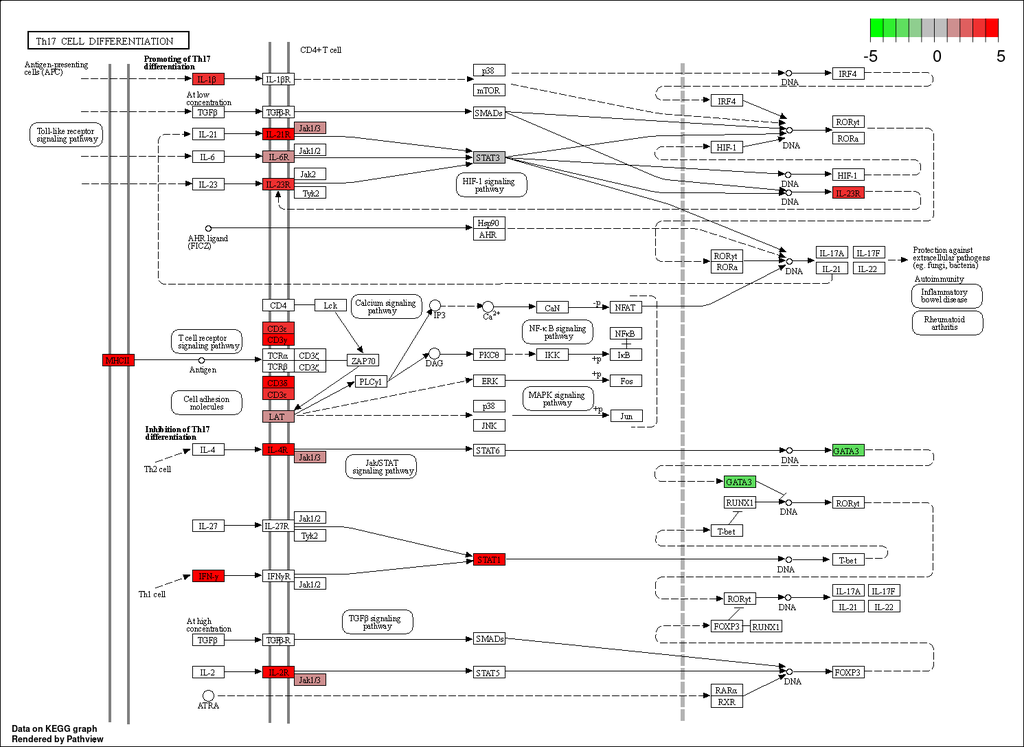

mmu04659 - Th17 cell differentiation

## GO term enrichment analysis

`clusterProfiler` can also perform over-representation analysis on GO terms using the function `enrichGO()`. For this analysis we will use Ensembl gene IDs instead of Entrez IDs and in order to do this we need to load another package which contains the mouse database called `org.Mm.eg.db`.

To run the GO enrichment analysis, this time we also need a couple of extra things. Firstly, we should provide a list of the ‘universe’ of all the genes in our DE analysis not just the ones we have selected as significant.

Gene Ontology terms are divided into 3 categories.

For this analysis we will narrow our search terms in the ‘Biological Processes’ Ontology so we can add the parameter “BP” with the ‘ont’ argument (the default is Molecular Functions).

```r
library(org.Mm.eg.db)

# get ENSEMBL IDs for significant genes
sig_genes_ensembl <-  res_d11_shrink %>%
  drop_na(padj) %>%
  filter(padj < 0.01 & abs(log2FoldChange) > 2) %>%
  pull(GeneID)

# get names for all the genes we have data for
universe <- res_d11_shrink$GeneID

# run enrichment analysis
go_results <- enrichGO(gene = sig_genes_ensembl,
                       universe = universe,
                       OrgDb = org.Mm.eg.db,
                       keyType = "ENSEMBL",
                       ont = "BP",
                       pvalueCutoff = 0.01,
                       readable = TRUE)
```

We can use the `barplot()` function to visualise the results. Count is the number of differentially expressed in each gene ontology term.

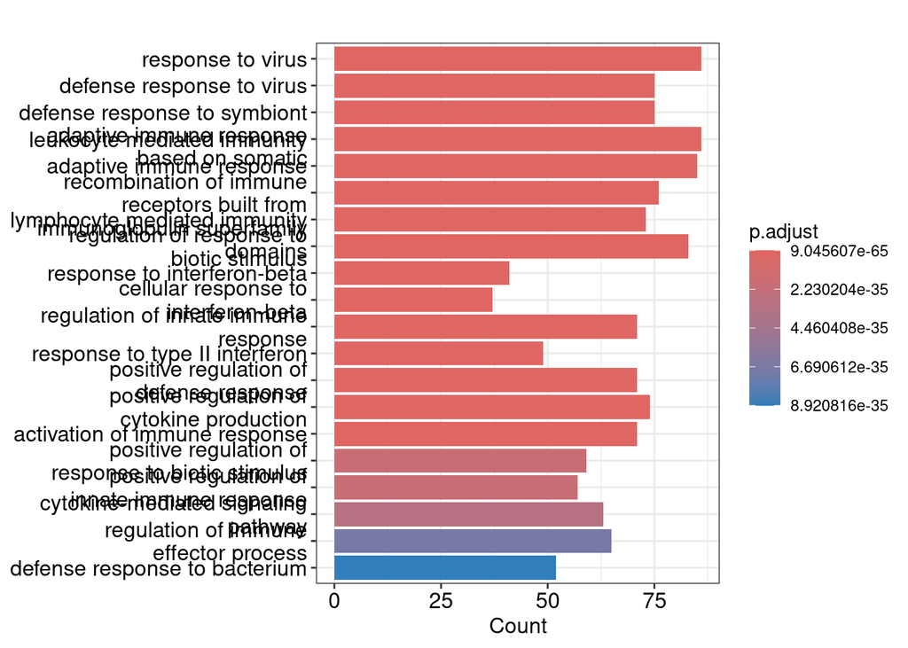

```r
barplot(go_results, showCategory = 20)
```

An alternative is the `dotplot()` version, which can be more informative. Gene ratio is Count divided by the number of genes in that GO term.

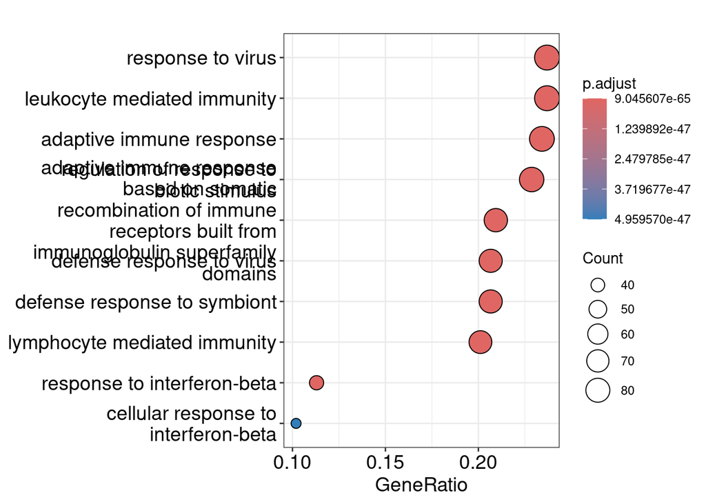

```r
dotplot(go_results, font.size = 14)
```

Another visualisation that can be nice to try is the `emapplot()` which shows the overlap between genes in the different GO terms.

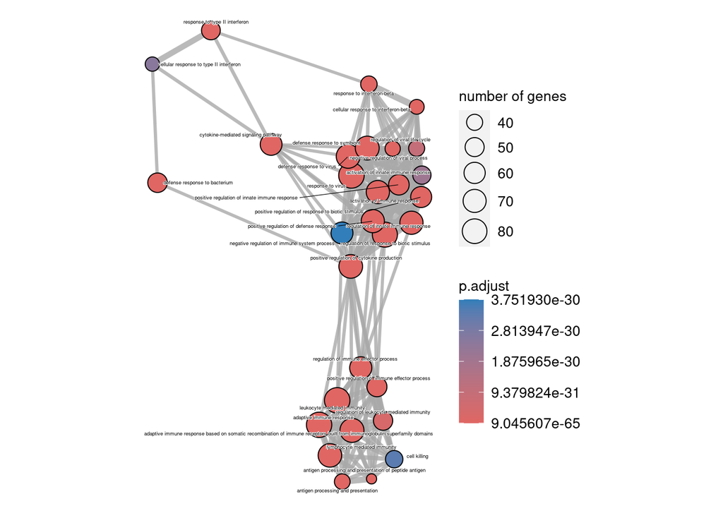

```r
library(enrichplot)
ego_pt <- pairwise_termsim(go_results)
emapplot(ego_pt, cex_label_category = 0.25)
```

## GSEA analysis

Gene Set Enrichment Analysis (GSEA) identifies gene sets that are enriched in the dataset between samples (Subramanian et al. 2005).

The software is distributed by the [Broad Institute](http://software.broadinstitute.org/gsea/index.jsp) and is freely available for use by academic and non-profit organisations. The Broad also provide a number of very well curated gene sets for testing against your data - the [Molecular Signatures Database (MSigDB)](http://software.broadinstitute.org/gsea/msigdb/index.jsp). These are collections of human genes. Fortunately, these lists have been translated to mouse equivalents by the Walter+Eliza Hall Institute Bioinformatics service and made available for [download](http://bioinf.wehi.edu.au/MSigDB/index.html). They are now also available from a recent R package [msigdbr](https://cran.r-project.org/web/packages/msigdbr/index.html), which we will use.

Let’s load `msigdbr` now.

```r
library(msigdbr)
```

The analysis is performed by:

1. ranking all genes in the data set
2. identifying in the ranked data set the rank positions of all members of the gene set
3. calculating an enrichment score (ES) that represents the difference between the observed rankings and that which would be expected assuming a random rank distribution.

The article describing the original software is available [here](http://www.pnas.org/content/102/43/15545.long), while this [commentary on GSEA](https://www.ncbi.nlm.nih.gov/pmc/articles/PMC1266131/) provides a shorter description.

We will use `clusterProfiler`’s [`GSEA`](http://yulab-smu.top/clusterProfiler-book/chapter2.html#gene-set-enrichment-analysis) package (Yu et al. 2012) that implements the same algorithm in R.

### Rank genes

We need to provide `GSEA` with a vector containing values for a given gene mtric, e.g. log(fold change), sorted in decreasing order.

To start with we will simply use a rank the genes based on their fold change.

We must exclude genes with no Ensembl ID.

Also, we should use the shrunk LFC values.

```r
ranked_genes <- res_d11_shrink %>%
  drop_na(GeneID, padj, log2FoldChange) %>%
  mutate(rank = log2FoldChange) %>%
  arrange(desc(rank)) %>%
  pull(rank, GeneID)
```

### Load pathways

We will load the MSigDB Hallmark gene set with `msigdbr`, setting the `category` parameter to ‘H’ for **H**allmark gene set. The object created is a `tibble` with information on each {gene set; gene} pair (one per row). We will only keep the the gene set name, gene Ensembl ID.

```r
term2gene <- msigdbr(species = "Mus musculus", category = "H") %>%
  dplyr::select(gs_name, ensembl_gene)
term2name <- msigdbr(species = "Mus musculus", category = "H") %>%
  dplyr::select(gs_name, gs_description) %>%
  distinct()
```

### Conduct analysis

Arguments passed to `GSEA` include:

- ranked genes
- pathways
- gene set minimum size
- gene set maximum size

```r
gsea_results <- GSEA(ranked_genes,
                     TERM2GENE = term2gene,
                     TERM2NAME = term2name,
                     pvalueCutoff = 1.00,
                     minGSSize = 15,
                     maxGSSize = 500)
```

```
## preparing geneSet collections...
```

```
## GSEA analysis...
```

```
## leading edge analysis...
```

```
## done...
```

Let’s look at the top 10 results, based on the *normalised enrichment score* (NES):

```r
gsea_results %>%
  # convert to regular data.frame/tibble
  as_tibble() %>%
  # get the top genes based on adjusted p-value
  top_n(10, wt = -p.adjust) %>%
  # sort by normalised enrichment score
  arrange(desc(abs(NES)))
```

|  | ID | Description | setSize | enrichmentScore | NES | pvalue | p.adjust | qvalue | rank | leading_edge |
| --- | --- | --- | --- | --- | --- | --- | --- | --- | --- | --- |
| 1 | HALLMARK_INTERFERON_ALPHA_RESPONSE | Genes up-regulated in response to alpha interferon proteins. | 96 | 0.953 | 1.39 | 1.72e-10 | 2.87e-09 | 2.30e-09 | 766 | tags=80%, list=4%, signal=77% |
| 2 | HALLMARK_INTERFERON_GAMMA_RESPONSE | Genes up-regulated in response to IFNG [GeneID=3458]. | 202 | 0.946 | 1.386 | 1.00e-10 | 2.50e-09 | 2.00e-09 | 891 | tags=71%, list=5%, signal=68% |
| 3 | HALLMARK_ALLOGRAFT_REJECTION | Genes up-regulated during transplant rejection. | 194 | 0.932 | 1.367 | 1.00e-10 | 2.50e-09 | 2.00e-09 | 911 | tags=47%, list=5%, signal=45% |
| 4 | HALLMARK_IL6_JAK_STAT3_SIGNALING | Genes up-regulated by IL6 [GeneID=3569] via STAT3 [GeneID=6774], e.g., during acute phase response. | 82 | 0.924 | 1.352 | 1.41e-05 | 1.18e-04 | 9.41e-05 | 1086 | tags=51%, list=6%, signal=48% |
| 5 | HALLMARK_INFLAMMATORY_RESPONSE | Genes defining inflammatory response. | 191 | 0.9 | 1.319 | 1.33e-07 | 1.67e-06 | 1.33e-06 | 854 | tags=36%, list=5%, signal=35% |
| 6 | HALLMARK_TNFA_SIGNALING_VIA_NFKB | Genes regulated by NF-kB in response to TNF [GeneID=7124]. | 194 | 0.892 | 1.307 | 9.95e-07 | 9.95e-06 | 7.96e-06 | 1154 | tags=36%, list=7%, signal=34% |
| 7 | HALLMARK_APOPTOSIS | Genes mediating programmed cell death (apoptosis) by activation of caspases. | 158 | 0.881 | 1.291 | 7.40e-05 | 4.11e-04 | 3.29e-04 | 1110 | tags=23%, list=6%, signal=22% |
| 8 | HALLMARK_COMPLEMENT | Genes encoding components of the complement system, which is part of the innate immune system. | 185 | 0.876 | 1.282 | 3.22e-05 | 2.30e-04 | 1.84e-04 | 1123 | tags=30%, list=6%, signal=29% |
| 9 | HALLMARK_IL2_STAT5_SIGNALING | Genes up-regulated by STAT5 in response to IL2 stimulation. | 193 | 0.872 | 1.278 | 5.76e-05 | 3.60e-04 | 2.88e-04 | 918 | tags=21%, list=5%, signal=20% |
| 10 | HALLMARK_COAGULATION | Genes encoding components of blood coagulation system; also up-regulated in platelets. | 117 | 0.861 | 1.261 | 4.31e-03 | 2.16e-02 | 1.73e-02 | 1095 | tags=22%, list=6%, signal=21% |

### Enrichment score plot

The enrichment score plot displays along the x-axis that represents the decreasing gene rank:

- genes involved in the pathway under scrutiny: one black tick per gene in the pathway (no tick for genes not in the pathway)
- the enrichment score: the green curve shows the difference between the observed rankings and that which would be expected assuming a random rank distribution.

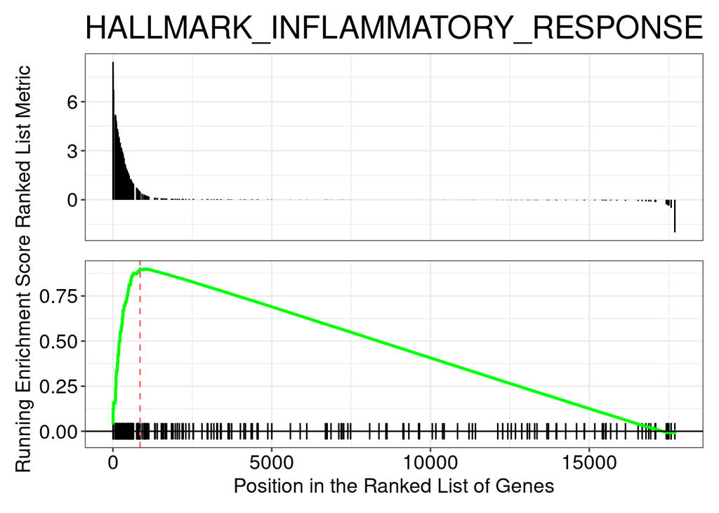

```r
gseaplot(gsea_results,
         geneSetID = "HALLMARK_INFLAMMATORY_RESPONSE",
         title = "HALLMARK_INFLAMMATORY_RESPONSE")
```

Remember to check the [GSEA article](http://www.pnas.org/content/102/43/15545.full) for the complete explanation.

### Exercise 2

Another common way to rank the genes is to order by p-value while sorting, so that upregulated genes are at the start and downregulated at the end. You can do this combining the sign of the fold change and the p-value.

1. Rank the genes by statistical significance - you will need to create a new ranking value using `-log10(pvalue) * sign(log2FoldChange)`.
2. Run GSEA using the new ranked genes and the H pathways.
3. Conduct the same analysis for the day 33 Infected vs Uninfected contrast. Make sure to first load the results using the following:

   ```r
   # read d33 data in
   res_d33_shrink <- readRDS("preprocessed/r_objects/res_infected_vs_uninfected_d33_annotated_shrink.rds")
   ```

**Answer**

First load the pathway details if you have not already done so.

```r
library(msigdbr)
term2gene <- msigdbr(species = "Mus musculus", category = "H") %>%
  dplyr::select(gs_name, ensembl_gene)
term2name <- msigdbr(species = "Mus musculus", category = "H") %>%
  dplyr::select(gs_name, gs_description) %>%
  distinct()
```

**1.**

We can generate a new table of ranked genes using the new ranking based on p-values:

```r
# rank genes
ranked_genes_pval <- res_d11_shrink %>%
  drop_na(GeneID, pvalue, log2FoldChange) %>%
  mutate(rank = -log10(pvalue) * sign(log2FoldChange)) %>%
  arrange(desc(rank)) %>%
  pull(rank, GeneID)
```

The result is a named vector with sorted p-values. Remember that a high `-log10(pvalue)` corresponds to a very low (i.e. significant) p-value. By multiplying `-log10(pvalue)` by the sign of the `log2FoldChange` we ensure that our p-values are ordered from upregulated to downregulated genes. Here is a peek at the first (`head()`) and last (`tail()`) few genes of our ranked gene vector:

```r
head(ranked_genes_pval)
```

```
## ENSMUSG00000046879 ENSMUSG00000078853 ENSMUSG00000069874 ENSMUSG00000060586
##          119.08761          111.37314          110.87312          110.33734
## ENSMUSG00000024610 ENSMUSG00000054072
##           96.34973           95.07151
```

```r
tail(ranked_genes_pval)
```

```
## ENSMUSG00000066443 ENSMUSG00000040488 ENSMUSG00000004891 ENSMUSG00000021342
##          -7.433218          -7.710282          -7.728996          -8.147132
## ENSMUSG00000066842 ENSMUSG00000020154
##          -8.628705         -11.697586
```

**2.**

Once we have our ranked genes, we can use the `GSEA()` function as demonstrated earlier:

```r
# conduct analysis:
gsea_res_pval <- GSEA(ranked_genes_pval,
                      TERM2GENE = term2gene,
                      TERM2NAME = term2name,
                      pvalueCutoff = 1.00,
                      minGSSize = 15,
                      maxGSSize = 500)
```

```
## preparing geneSet collections...
```

```
## GSEA analysis...
```

```
## leading edge analysis...
```

```
## done...
```

To view the results we can convert this object to a regular data.frame/tibble, extract the top results based on p-value and sort them by the normalised enrichment score:

```r
gsea_res_pval %>%
  as_tibble() %>%
  top_n(10, wt=-p.adjust) %>%
  arrange(desc(abs(NES)))
```

|  | ID | Description | setSize | enrichmentScore | NES | pvalue | p.adjust | qvalue | rank | leading_edge |
| --- | --- | --- | --- | --- | --- | --- | --- | --- | --- | --- |
| 1 | HALLMARK_OXIDATIVE_PHOSPHORYLATION | Genes encoding proteins involved in oxidative phosphorylation. | 199 | -0.506 | -2.025 | 2.30e-08 | 2.88e-07 | 2.24e-07 | 4620 | tags=55%, list=23%, signal=43% |
| 2 | HALLMARK_INTERFERON_ALPHA_RESPONSE | Genes up-regulated in response to alpha interferon proteins. | 97 | 0.954 | 1.95 | 1.00e-10 | 1.67e-09 | 1.30e-09 | 860 | tags=84%, list=4%, signal=80% |
| 3 | HALLMARK_INTERFERON_GAMMA_RESPONSE | Genes up-regulated in response to IFNG [GeneID=3458]. | 203 | 0.948 | 1.946 | 1.00e-10 | 1.67e-09 | 1.30e-09 | 865 | tags=71%, list=4%, signal=69% |
| 4 | HALLMARK_ALLOGRAFT_REJECTION | Genes up-regulated during transplant rejection. | 196 | 0.905 | 1.863 | 1.00e-10 | 1.67e-09 | 1.30e-09 | 915 | tags=45%, list=5%, signal=43% |
| 5 | HALLMARK_IL6_JAK_STAT3_SIGNALING | Genes up-regulated by IL6 [GeneID=3569] via STAT3 [GeneID=6774], e.g., during acute phase response. | 84 | 0.887 | 1.799 | 1.19e-05 | 7.41e-05 | 5.77e-05 | 1491 | tags=56%, list=7%, signal=52% |
| 6 | HALLMARK_INFLAMMATORY_RESPONSE | Genes defining inflammatory response. | 196 | 0.837 | 1.722 | 4.37e-07 | 4.37e-06 | 3.40e-06 | 1199 | tags=39%, list=6%, signal=37% |
| 7 | HALLMARK_COMPLEMENT | Genes encoding components of the complement system, which is part of the innate immune system. | 189 | 0.824 | 1.695 | 3.35e-06 | 2.79e-05 | 2.17e-05 | 1358 | tags=32%, list=7%, signal=30% |
| 8 | HALLMARK_TNFA_SIGNALING_VIA_NFKB | Genes regulated by NF-kB in response to TNF [GeneID=7124]. | 196 | 0.815 | 1.676 | 8.40e-06 | 6.00e-05 | 4.67e-05 | 1702 | tags=43%, list=8%, signal=40% |
| 9 | HALLMARK_APOPTOSIS | Genes mediating programmed cell death (apoptosis) by activation of caspases. | 158 | 0.811 | 1.666 | 1.60e-04 | 8.89e-04 | 6.92e-04 | 1621 | tags=32%, list=8%, signal=29% |
| 10 | HALLMARK_IL2_STAT5_SIGNALING | Genes up-regulated by STAT5 in response to IL2 stimulation. | 195 | 0.78 | 1.603 | 2.62e-04 | 1.31e-03 | 1.02e-03 | 1158 | tags=25%, list=6%, signal=24% |

**3.**

We repeat the analysis we just did for d11, but using the d33 contrast instead:

```r
# rank genes
ranked_genes_d33 <- res_d33_shrink %>%
  drop_na(GeneID, pvalue, log2FoldChange) %>%
  mutate(rank = -log10(pvalue) * sign(log2FoldChange)) %>%
  arrange(desc(rank)) %>%
  pull(rank, GeneID)

# perform analysis
gsea_res_d33 <- GSEA(ranked_genes_d33,
                    TERM2GENE = term2gene,
                    TERM2NAME = term2name,
                    pvalueCutoff = 1.00,
                    minGSSize = 15,
                    maxGSSize = 500)
```

```
## preparing geneSet collections...
```

```
## GSEA analysis...
```

```
## leading edge analysis...
```

```
## done...
```

View the results:

```r
as_tibble(gsea_res_d33) %>%
  top_n(10, wt = -p.adjust) %>%
  arrange(desc(abs(NES)))
```

|  | ID | Description | setSize | enrichmentScore | NES | pvalue | p.adjust | qvalue | rank | leading_edge |
| --- | --- | --- | --- | --- | --- | --- | --- | --- | --- | --- |
| 1 | HALLMARK_INTERFERON_ALPHA_RESPONSE | Genes up-regulated in response to alpha interferon proteins. | 97 | 0.938 | 1.776 | 1.00e-10 | 1.18e-09 | 9.21e-10 | 930 | tags=76%, list=5%, signal=73% |
| 2 | HALLMARK_INTERFERON_GAMMA_RESPONSE | Genes up-regulated in response to IFNG [GeneID=3458]. | 203 | 0.93 | 1.742 | 1.00e-10 | 1.18e-09 | 9.21e-10 | 993 | tags=67%, list=5%, signal=65% |
| 3 | HALLMARK_ALLOGRAFT_REJECTION | Genes up-regulated during transplant rejection. | 196 | 0.915 | 1.715 | 1.00e-10 | 1.18e-09 | 9.21e-10 | 1079 | tags=55%, list=5%, signal=53% |
| 4 | HALLMARK_IL6_JAK_STAT3_SIGNALING | Genes up-regulated by IL6 [GeneID=3569] via STAT3 [GeneID=6774], e.g., during acute phase response. | 84 | 0.878 | 1.67 | 2.79e-06 | 2.18e-05 | 1.71e-05 | 1265 | tags=58%, list=6%, signal=55% |
| 5 | HALLMARK_INFLAMMATORY_RESPONSE | Genes defining inflammatory response. | 196 | 0.869 | 1.63 | 1.00e-10 | 1.18e-09 | 9.21e-10 | 1448 | tags=47%, list=7%, signal=44% |
| 6 | HALLMARK_COMPLEMENT | Genes encoding components of the complement system, which is part of the innate immune system. | 189 | 0.823 | 1.545 | 6.61e-07 | 6.22e-06 | 4.87e-06 | 1259 | tags=29%, list=6%, signal=27% |
| 7 | HALLMARK_IL2_STAT5_SIGNALING | Genes up-regulated by STAT5 in response to IL2 stimulation. | 195 | 0.783 | 1.467 | 7.77e-05 | 5.21e-04 | 4.09e-04 | 1727 | tags=33%, list=9%, signal=31% |
| 8 | HALLMARK_KRAS_SIGNALING_UP | Genes up-regulated by KRAS activation. | 196 | 0.77 | 1.443 | 3.82e-04 | 2.24e-03 | 1.76e-03 | 1660 | tags=28%, list=8%, signal=26% |
| 9 | HALLMARK_TNFA_SIGNALING_VIA_NFKB | Genes regulated by NF-kB in response to TNF [GeneID=7124]. | 196 | 0.76 | 1.425 | 8.32e-04 | 4.35e-03 | 3.41e-03 | 1525 | tags=36%, list=8%, signal=33% |
| 10 | HALLMARK_APOPTOSIS | Genes mediating programmed cell death (apoptosis) by activation of caspases. | 158 | 0.753 | 1.418 | 3.04e-03 | 1.43e-02 | 1.12e-02 | 1771 | tags=31%, list=9%, signal=28% |

# References

Luo, Weijun, Brouwer, and Cory. 2013. “Pathview: An R/Bioconductor Package for Pathway-Based Data Integration and Visualization.” *Bioinformatics* 29 (14): 1830–1. https://doi.org/10.1093/bioinformatics/btt285.

Subramanian, Aravind, Pablo Tamayo, Vamsi K. Mootha, Sayan Mukherjee, Benjamin L. Ebert, Michael A. Gillette, Amanda Paulovich, et al. 2005. “Gene Set Enrichment Analysis: A Knowledge-Based Approach for Interpreting Genome-Wide Expression Profiles.” *Proceedings of the National Academy of Sciences* 102 (43): 15545–50. https://doi.org/10.1073/pnas.0506580102.

Yu, Guangchuang, Li-Gen Wang, Yanyan Han, and Qing-Yu He. 2012. “ClusterProfiler: An R Package for Comparing Biological Themes Among Gene Clusters.” *OMICS: A Journal of Integrative Biology* 16 (5): 284–87. https://doi.org/10.1089/omi.2011.0118.